# Assignment 1

DATA 311 - Machine Learning

Author

Maxim Storozhuk (40965642)

# Exercise 1

This exercise is both a **regression** and **supervised** problem.

So, the answers are **B** and **C**.

# Exercise 2

```r
data <- read.csv("assignmentData/A1/abalone.data") #all data will now be stored in the "data" variable
str(data)
```

```
'data.frame':   4176 obs. of  9 variables:
 $ M      : chr  "M" "F" "M" "I" ...
 $ X0.455 : num  0.35 0.53 0.44 0.33 0.425 0.53 0.545 0.475 0.55 0.525 ...
 $ X0.365 : num  0.265 0.42 0.365 0.255 0.3 0.415 0.425 0.37 0.44 0.38 ...
 $ X0.095 : num  0.09 0.135 0.125 0.08 0.095 0.15 0.125 0.125 0.15 0.14 ...
 $ X0.514 : num  0.226 0.677 0.516 0.205 0.351 ...
 $ X0.2245: num  0.0995 0.2565 0.2155 0.0895 0.141 ...
 $ X0.101 : num  0.0485 0.1415 0.114 0.0395 0.0775 ...
 $ X0.15  : num  0.07 0.21 0.155 0.055 0.12 0.33 0.26 0.165 0.32 0.21 ...
 $ X15    : int  7 9 10 7 8 20 16 9 19 14 ...
```

## Exercise 2b

This part is not necessary, as str(data) has already verified that all datatypes are correct.

However, I will rename every column to what data it actually represents, using information from the [official website](https://archive.ics.uci.edu/dataset/1/abalone).

```r
library(dplyr) #we will need this throughout the assignment
library(knitr) #we will need this throughout the assignment
names(data) #names of columns before renaming
```

```
[1] "M"       "X0.455"  "X0.365"  "X0.095"  "X0.514"  "X0.2245" "X0.101"
[8] "X0.15"   "X15"
```

```r
data <- data %>% rename(Sex = M)
data <- data %>% rename(Length = X0.455)
data <- data %>% rename(Diameter = X0.365)
data <- data %>% rename(Height = X0.095)
data <- data %>% rename(Whole_Weight = X0.514)
data <- data %>% rename(Shucked_Weight = X0.2245)
data <- data %>% rename(Viscera_Weight = X0.101)
data <- data %>% rename(Shell_Weight = X0.15)
data <- data %>% rename(Rings = X15)
names(data) #names of columns after renaming
```

```
[1] "Sex"            "Length"         "Diameter"       "Height"
[5] "Whole_Weight"   "Shucked_Weight" "Viscera_Weight" "Shell_Weight"
[9] "Rings"
```

# Exercise 3

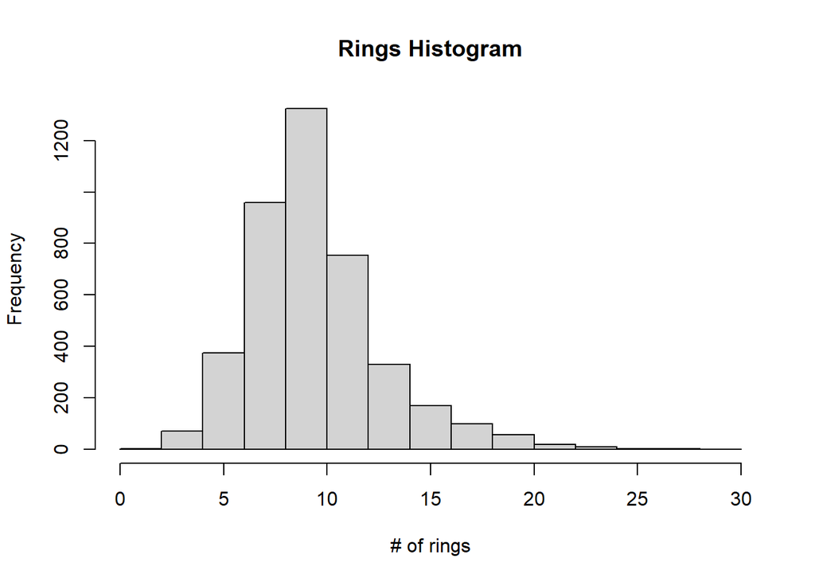

```r
hist(data$Rings,
     main = "Rings Histogram",
     xlab = "# of rings")
```

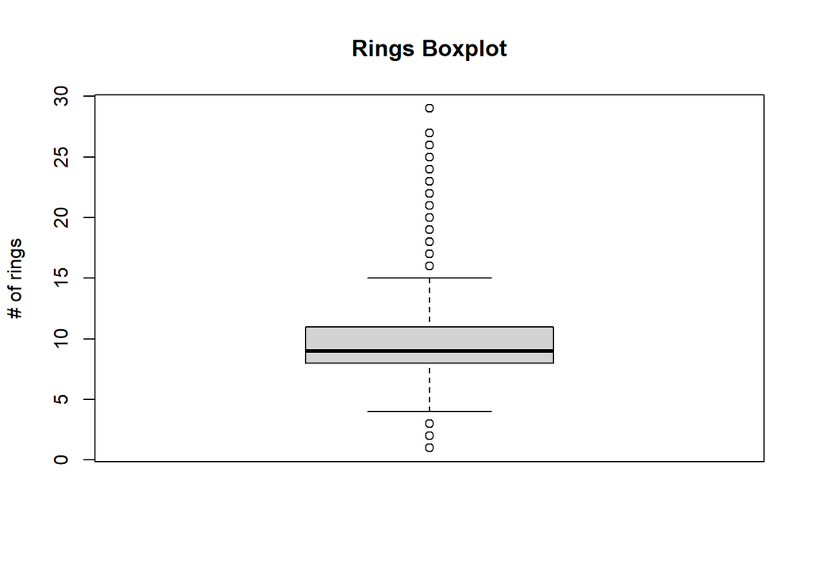

```r
boxplot(data$Rings,
     main = "Rings Boxplot",
     ylab = "# of rings")
```

The assumptions for the linear model come as follows:

1. Linearity: The relationship between the independent and dependent variables should be (approximately) linear.
2. Independence of Errors: The errors (residuals) in the model should be independent of each other.
3. Homoscedasticity: The variance of the residuals is constant across all levels of the predictors.

In the histogram and boxplot, we are only looking at the dependent variable. We are not yet looking at the relationship between the dependent and independent variables. Therefore, we can not say that we break any of the assumptions of the linear model.

The distribution can be described as normal, as more than 95% of the values follow a normal distribution. There is a bit of a right tail with some abalones being on the older side, but this doesn’t represent a significant amount of them.

# Exercise 4

```r
set.seed(40965642) #student number as seed for reproducibility
n <- nrow(data) #gets the number of rows in the data set
indices <- sample(1:n, size = n*0.5) #indices will store n/2 indices which will be a part of the training set

train_data <- data[indices, ] #training data will be stored in train_data
test_data <- data[-indices, ] #testing data will be stored in test_data

dim(train_data) #Checks to make sure that we split the data sets up properly
```

```
[1] 2088    9
```

```r
head(train_data)
```

|  | Sex | Length | Diameter | Height | Whole_Weight | Shucked_Weight | Viscera_Weight | Shell_Weight | Rings |
| --- | --- | --- | --- | --- | --- | --- | --- | --- | --- |
| 1187 | M | 0.685 | 0.520 | 0.165 | 1.5190 | 0.6990 | 0.3685 | 0.400 | 10 |
| 3175 | I | 0.510 | 0.405 | 0.120 | 0.6100 | 0.2290 | 0.1310 | 0.235 | 11 |
| 1623 | F | 0.565 | 0.440 | 0.150 | 0.8630 | 0.4350 | 0.1490 | 0.270 | 9 |
| 3721 | M | 0.430 | 0.310 | 0.130 | 0.6485 | 0.2735 | 0.1630 | 0.184 | 9 |
| 2383 | F | 0.525 | 0.390 | 0.135 | 0.6005 | 0.2265 | 0.1310 | 0.210 | 16 |
| 58 | I | 0.245 | 0.190 | 0.060 | 0.0860 | 0.0420 | 0.0140 | 0.025 | 4 |

```r
summary(train_data)
```

```
     Sex                Length          Diameter         Height
 Length:2088        Min.   :0.1400   Min.   :0.100   Min.   :0.0000
 Class :character   1st Qu.:0.4500   1st Qu.:0.345   1st Qu.:0.1150
 Mode  :character   Median :0.5400   Median :0.420   Median :0.1400
                    Mean   :0.5213   Mean   :0.406   Mean   :0.1387
                    3rd Qu.:0.6100   3rd Qu.:0.480   3rd Qu.:0.1650
                    Max.   :0.7700   Max.   :0.625   Max.   :1.1300
  Whole_Weight    Shucked_Weight   Viscera_Weight    Shell_Weight
 Min.   :0.0140   Min.   :0.0045   Min.   :0.0025   Min.   :0.0040
 1st Qu.:0.4397   1st Qu.:0.1860   1st Qu.:0.0915   1st Qu.:0.1300
 Median :0.7905   Median :0.3300   Median :0.1683   Median :0.2300
 Mean   :0.8132   Mean   :0.3509   Mean   :0.1773   Mean   :0.2348
 3rd Qu.:1.1276   3rd Qu.:0.4895   3rd Qu.:0.2475   3rd Qu.:0.3200
 Max.   :2.5500   Max.   :1.2530   Max.   :0.5410   Max.   :1.0050
     Rings
 Min.   : 2.000
 1st Qu.: 8.000
 Median : 9.000
 Mean   : 9.947
 3rd Qu.:11.000
 Max.   :29.000
```

```r
dim(test_data) #Checks to make sure that we split the data sets up properly
```

```
[1] 2088    9
```

```r
head(test_data)
```

|  | Sex | Length | Diameter | Height | Whole_Weight | Shucked_Weight | Viscera_Weight | Shell_Weight | Rings |
| --- | --- | --- | --- | --- | --- | --- | --- | --- | --- |
| 2 | F | 0.530 | 0.420 | 0.135 | 0.6770 | 0.2565 | 0.1415 | 0.210 | 9 |
| 3 | M | 0.440 | 0.365 | 0.125 | 0.5160 | 0.2155 | 0.1140 | 0.155 | 10 |
| 4 | I | 0.330 | 0.255 | 0.080 | 0.2050 | 0.0895 | 0.0395 | 0.055 | 7 |
| 7 | F | 0.545 | 0.425 | 0.125 | 0.7680 | 0.2940 | 0.1495 | 0.260 | 16 |
| 14 | F | 0.470 | 0.355 | 0.100 | 0.4755 | 0.1675 | 0.0805 | 0.185 | 10 |
| 18 | M | 0.365 | 0.295 | 0.080 | 0.2555 | 0.0970 | 0.0430 | 0.100 | 7 |

```r
summary(test_data)
```

```
     Sex                Length          Diameter          Height
 Length:2088        Min.   :0.0750   Min.   :0.0550   Min.   :0.0000
 Class :character   1st Qu.:0.4500   1st Qu.:0.3500   1st Qu.:0.1150
 Mode  :character   Median :0.5450   Median :0.4250   Median :0.1450
                    Mean   :0.5267   Mean   :0.4098   Mean   :0.1403
                    3rd Qu.:0.6200   3rd Qu.:0.4850   3rd Qu.:0.1700
                    Max.   :0.8150   Max.   :0.6500   Max.   :0.5150
  Whole_Weight    Shucked_Weight   Viscera_Weight     Shell_Weight
 Min.   :0.0020   Min.   :0.0010   Min.   :0.00050   Min.   :0.0015
 1st Qu.:0.4444   1st Qu.:0.1865   1st Qu.:0.09588   1st Qu.:0.1300
 Median :0.8043   Median :0.3425   Median :0.17150   Median :0.2360
 Mean   :0.8444   Mean   :0.3679   Mean   :0.18395   Mean   :0.2429
 3rd Qu.:1.1806   3rd Qu.:0.5161   3rd Qu.:0.25862   3rd Qu.:0.3350
 Max.   :2.8255   Max.   :1.4880   Max.   :0.76000   Max.   :0.8970
     Rings
 Min.   : 1.000
 1st Qu.: 8.000
 Median :10.000
 Mean   : 9.918
 3rd Qu.:11.000
 Max.   :24.000
```

# Exercise 5

```r
lengthlm <- lm(Rings~Length, data = train_data) #fits a simple linear regression model with rings as the response variable and length as the predictor variable
summary(lengthlm) #displays the summary of the simple linear regression model
```

```
Call:
lm(formula = Rings ~ Length, data = train_data)

Residuals:
    Min      1Q  Median      3Q     Max
-5.0229 -1.7724 -0.7846  0.9302 16.6085

Coefficients:
            Estimate Std. Error t value Pr(>|t|)
(Intercept)   1.8784     0.2744   6.846 9.99e-12 ***
Length       15.4784     0.5133  30.154  < 2e-16 ***
---
Signif. codes:  0 '***' 0.001 '**' 0.01 '*' 0.05 '.' 0.1 ' ' 1

Residual standard error: 2.777 on 2086 degrees of freedom
Multiple R-squared:  0.3036,    Adjusted R-squared:  0.3032
F-statistic: 909.3 on 1 and 2086 DF,  p-value: < 2.2e-16
```

```r
e5R2 <- summary(lengthlm)$adj.r.squared #for use in exercise 22
e5RSE <- summary(lengthlm)$sigma #for use in exercise 22
testlengthlm <- predict(lengthlm, test_data) #code taken from lab 2
e5MSE <- mean((test_data$Rings - testlengthlm)^2) #for use in exercise 22
```

Yes, we can tell that there is a significant relationship by looking at the Pr(>|t|) column in the Length Row. This p value is very small, indicating that there is a significant relationship between Rings and Length.

# Exercise 6

The coefficient of determination R^2 is equal to 0.3036. This means that 30.36% of the variance in Rings is explained by Length.

# Exercise 7

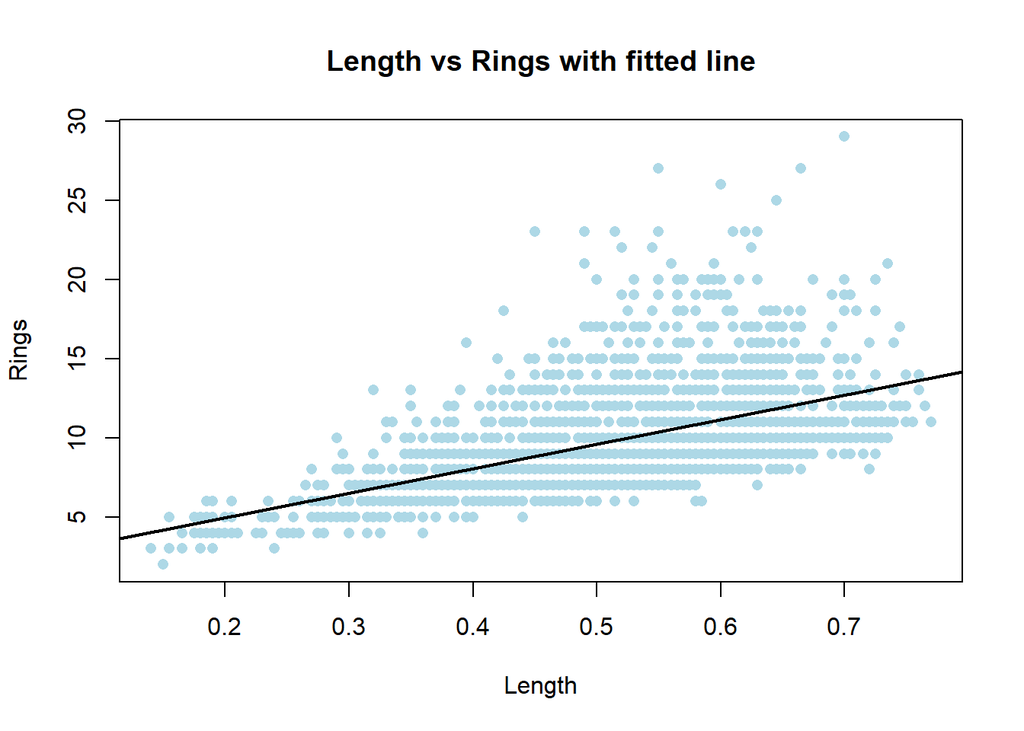

```r
plot(train_data$Length, train_data$Rings, #scatter plot command
     main = "Length vs Rings with fitted line",
     xlab = "Length",
     ylab = "Rings",
     pch = 16,
     col = "lightblue")
abline(lengthlm, lwd = 2) #ab line adds the fitted line to the scatterplot
```

# Exercise 8

I will restate the assumptions of the linear model here:

1. Linearity: The relationship between the independent and dependent variables should be (approximately) linear.
2. Independence of Errors: The errors (residuals) in the model should be independent of each other.
3. Homoscedasticity: The variance of the residuals is constant across all levels of the predictors.

Do these assumptions hold?

1. Linearity: This assumption holds. The scatterplot holds a linear average rate of growth.
2. Independence of Errors: This assumption holds. The residuals are independent of each other.
3. Homoscedasticity: This assumption does **NOT** hold. We can see a cone shape appear in the scatterplot, with the residuals getting larger as the values increase. This is an example of heteroscedasticity, which means this assumption is not satisfied.

# Exercise 9

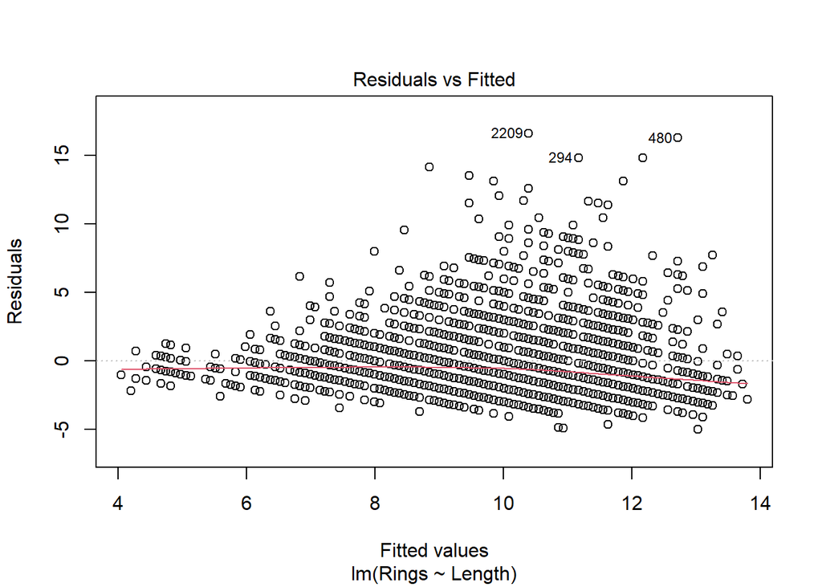

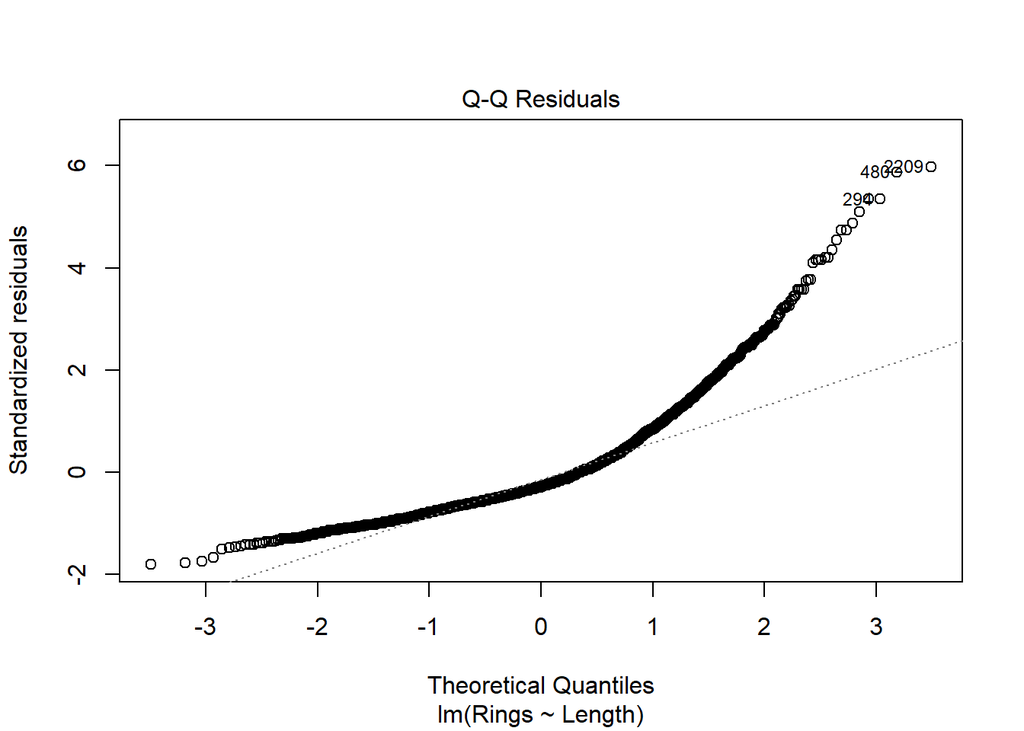

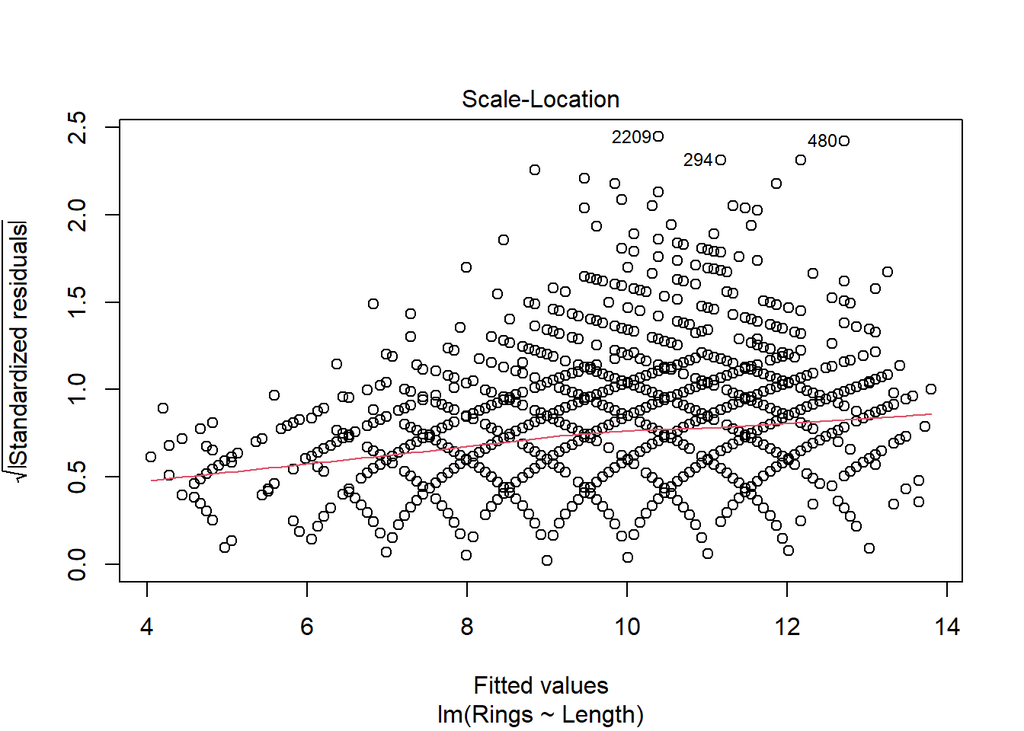

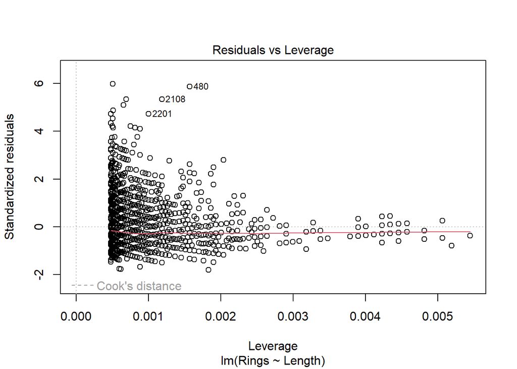

```r
plot(lengthlm)
```

To answer if the residuals are normally distributed, we look at the Q-Q Residual Plot. If the points on the plot follow the reference line, the residuals are normally distributed. However, both the left and right tails deviate from the reference line. This means that the residuals are not normally distributed.

# Exercise 10

```r
lengthqm <- lm(Rings~Length + I(Length^2), data = train_data) #I function is used as outlined in lecture 5
summary(lengthqm)
```

```
Call:
lm(formula = Rings ~ Length + I(Length^2), data = train_data)

Residuals:
    Min      1Q  Median      3Q     Max
-5.0186 -1.7856 -0.7409  0.9844 16.7853

Coefficients:
            Estimate Std. Error t value Pr(>|t|)
(Intercept)  -1.6547     0.7946  -2.082   0.0374 *
Length       31.0761     3.3337   9.322  < 2e-16 ***
I(Length^2) -16.0895     3.3983  -4.735 2.34e-06 ***
---
Signif. codes:  0 '***' 0.001 '**' 0.01 '*' 0.05 '.' 0.1 ' ' 1

Residual standard error: 2.763 on 2085 degrees of freedom
Multiple R-squared:  0.311, Adjusted R-squared:  0.3103
F-statistic: 470.5 on 2 and 2085 DF,  p-value: < 2.2e-16
```

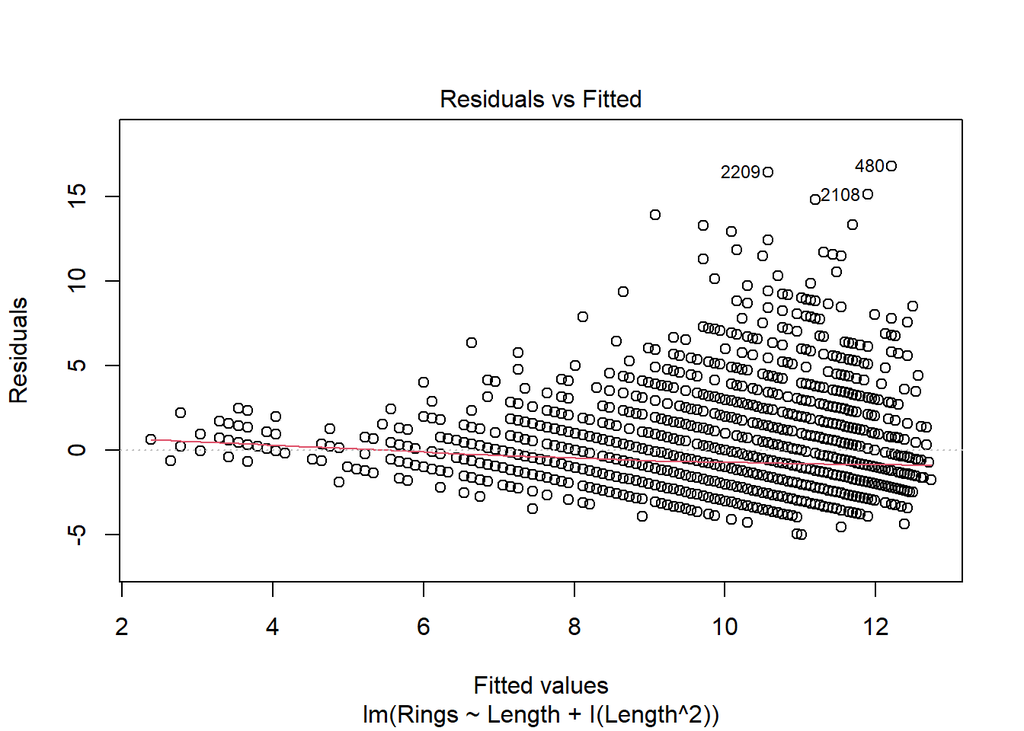

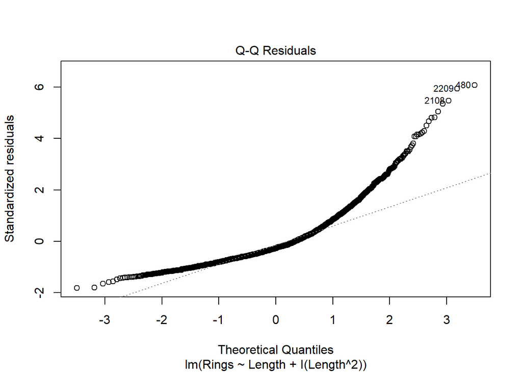

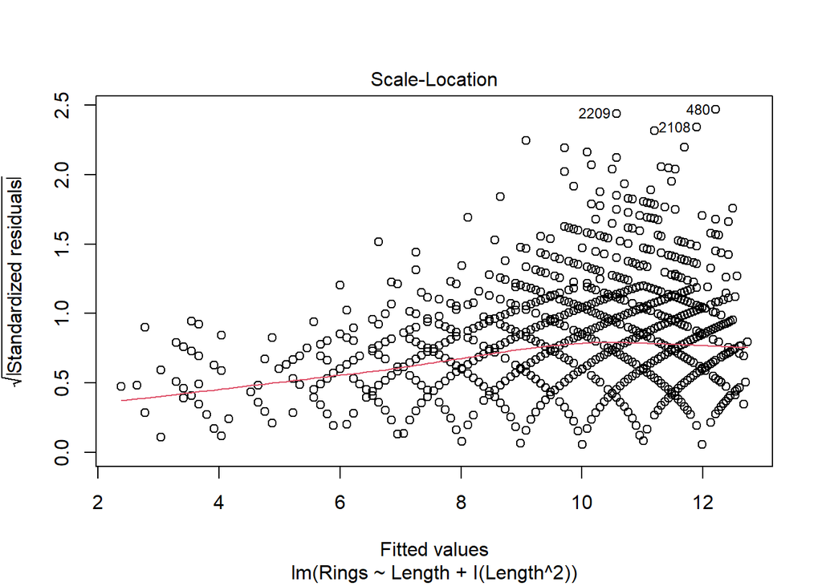

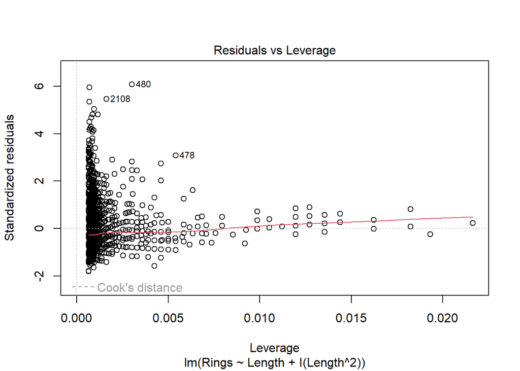

```r
plot(lengthqm)
```

```r
e10R2 <- summary(lengthqm)$adj.r.squared #for use in exercise 22
e10RSE <- summary(lengthqm)$sigma #for use in exercise 22
testlengthqm <- predict(lengthqm, test_data) #code taken from lab 2
e10MSE <- mean((test_data$Rings - testlengthqm)^2) #for use in exercise 22
```

The p-value is significant for the quadratic term Length^2. The adjusted R-Squared score is now 0.3103, up from 0.3032 when using the linear model. This means that the quadratic term is significant in helping predict the Rings variable. The Q-Q Residual Plot indicates that the residuals still are not normally distributed, as the reference line is not followed. The Scale-Location plot still indicates that the relationship is heteroscedastic. This is because the points are not normally scattered, we can see a pattern emerging.

# Exercise 11

```r
lengthSexlm <- lm(Rings~Length + factor(Sex), data = train_data) # factor is used as outliend in slides
summary(lengthSexlm)
```

```
Call:
lm(formula = Rings ~ Length + factor(Sex), data = train_data)

Residuals:
    Min      1Q  Median      3Q     Max
-5.3024 -1.7458 -0.6354  0.8596 16.2750

Coefficients:
             Estimate Std. Error t value Pr(>|t|)
(Intercept)    4.0658     0.3664  11.098   <2e-16 ***
Length        12.3703     0.6092  20.307   <2e-16 ***
factor(Sex)I  -1.5022     0.1745  -8.607   <2e-16 ***
factor(Sex)M  -0.2230     0.1457  -1.530    0.126
---
Signif. codes:  0 '***' 0.001 '**' 0.01 '*' 0.05 '.' 0.1 ' ' 1

Residual standard error: 2.725 on 2084 degrees of freedom
Multiple R-squared:  0.3301,    Adjusted R-squared:  0.3291
F-statistic: 342.3 on 3 and 2084 DF,  p-value: < 2.2e-16
```

```r
e11R2 <- summary(lengthSexlm)$adj.r.squared #for use in exercise 22
e11RSE <- summary(lengthSexlm)$sigma #for use in exercise 22
testlengthSexlm <- predict(lengthSexlm, test_data) #code taken from lab 2
e11MSE <- mean((test_data$Rings - testlengthSexlm)^2) #for use in exercise 22
```

Adding sex into the model ends up with dummy variables being used. Since there are three categories (F, I, M), two dummy variables are created; SexI, and SexM. SexF is treated as the reference level. The p-values indicate that the result is significant when the Sex of the abalone is I, but insignificant when the Sex is M. The Adjusted R-Squared value for this model is 0.3291, which is an improvement over the 0.3032 when using a linear model with only length, and the 0.3103 when using the polynomial model using length and length^2.

# Exercise 12

**FEMALE:** Rings = 4.0658 + 12.3703*Length + *(-0.223)*0* + *(-1.5022)*0*

**MALE:** Rings = 4.0658 + 12.3703*Length + (-0.223)*1 + *(-1.5022)*0*

# Exercise 13

**A: Female**

# Exercise 14

**D: Not enough information to say**

*P-Value was insignificant for SexM*

# Exercise 15

```r
lengthSexWeightlm <- step(lengthSexlm, #utilized chatgpt to help with syntax here, as I could not find syntax for forward selection covered anywhere in the course
                          scope = list(upper = lm(Rings~Length + factor(Sex) + Whole_Weight, data = train_data)),
                          direction = "forward",
                          steps = 1)
```

```
Start:  AIC=4190.7
Rings ~ Length + factor(Sex)

               Df Sum of Sq   RSS    AIC
+ Whole_Weight  1    68.229 15410 4183.5
<none>                      15478 4190.7

Step:  AIC=4183.47
Rings ~ Length + factor(Sex) + Whole_Weight
```

```r
summary(lengthSexWeightlm)
```

```
Call:
lm(formula = Rings ~ Length + factor(Sex) + Whole_Weight, data = train_data)

Residuals:
    Min      1Q  Median      3Q     Max
-5.1161 -1.7203 -0.6226  0.8855 15.9319

Coefficients:
             Estimate Std. Error t value Pr(>|t|)
(Intercept)    5.1217     0.5046  10.151  < 2e-16 ***
Length         8.7294     1.3442   6.494 1.04e-10 ***
factor(Sex)I  -1.4385     0.1754  -8.199 4.18e-16 ***
factor(Sex)M  -0.2358     0.1455  -1.621  0.10515
Whole_Weight   1.0157     0.3345   3.037  0.00242 **
---
Signif. codes:  0 '***' 0.001 '**' 0.01 '*' 0.05 '.' 0.1 ' ' 1

Residual standard error: 2.72 on 2083 degrees of freedom
Multiple R-squared:  0.333, Adjusted R-squared:  0.3318
F-statistic:   260 on 4 and 2083 DF,  p-value: < 2.2e-16
```

```r
e15R2 <- summary(lengthSexWeightlm)$adj.r.squared #for use in exercise 22
e15RSE <- summary(lengthSexWeightlm)$sigma #for use in exercise 22
testlengthSexWeightlm <- predict(lengthSexWeightlm, test_data) #code taken from lab 2
e15MSE <- mean((test_data$Rings - testlengthSexWeightlm)^2) #for use in exercise 22
```

# Exercise 16

```r
cor(subset(train_data, select = -Sex)) #subset command removes the Sex variable, as it is categorical rather than continuous
```

```
                  Length  Diameter    Height Whole_Weight Shucked_Weight
Length         1.0000000 0.9863132 0.7675498    0.9261711      0.9002993
Diameter       0.9863132 1.0000000 0.7755670    0.9277284      0.8956649
Height         0.7675498 0.7755670 1.0000000    0.7602183      0.7188112
Whole_Weight   0.9261711 0.9277284 0.7602183    1.0000000      0.9680777
Shucked_Weight 0.9002993 0.8956649 0.7188112    0.9680777      1.0000000
Viscera_Weight 0.9043835 0.9024373 0.7371442    0.9654706      0.9282203
Shell_Weight   0.8928095 0.9036416 0.7567959    0.9545052      0.8784177
Rings          0.5509730 0.5702174 0.5193412    0.5393680      0.4157272
               Viscera_Weight Shell_Weight     Rings
Length              0.9043835    0.8928095 0.5509730
Diameter            0.9024373    0.9036416 0.5702174
Height              0.7371442    0.7567959 0.5193412
Whole_Weight        0.9654706    0.9545052 0.5393680
Shucked_Weight      0.9282203    0.8784177 0.4157272
Viscera_Weight      1.0000000    0.9046675 0.5021031
Shell_Weight        0.9046675    1.0000000 0.6249294
Rings               0.5021031    0.6249294 1.0000000
```

The pair of predictor variables with the highest correlation are **Length** and **Diameter**. The problem with this much correlation between variables lies with the principle of multicollinearity. Multicollinearity can lead to unstable coefficient estimates, inflated standard errors, and reduction in overall interpretability.

# Exercise 17

```r
lengthWeightlm <- lm(Rings~Length + Whole_Weight, data = train_data)
summary(lengthWeightlm)
```

```
Call:
lm(formula = Rings ~ Length + Whole_Weight, data = train_data)

Residuals:
    Min      1Q  Median      3Q     Max
-5.1772 -1.7517 -0.7979  0.9507 16.1926

Coefficients:
             Estimate Std. Error t value Pr(>|t|)
(Intercept)    3.4934     0.4690   7.448 1.38e-13 ***
Length        10.1591     1.3557   7.494 9.84e-14 ***
Whole_Weight   1.4239     0.3361   4.236 2.37e-05 ***
---
Signif. codes:  0 '***' 0.001 '**' 0.01 '*' 0.05 '.' 0.1 ' ' 1

Residual standard error: 2.766 on 2085 degrees of freedom
Multiple R-squared:  0.3095,    Adjusted R-squared:  0.3089
F-statistic: 467.3 on 2 and 2085 DF,  p-value: < 2.2e-16
```

```r
e17R2 <- summary(lengthWeightlm)$adj.r.squared #for use in exercise 22
e17RSE <- summary(lengthWeightlm)$sigma #for use in exercise 22
testlengthWeightlm <- predict(lengthWeightlm, test_data) #code taken from lab 2
e17MSE <- mean((test_data$Rings - testlengthWeightlm)^2) #for use in exercise 22
```

**Multiple R-Squared Exercise 5: 0.3036**

**Adjusted R-Squared Exercise 5: 0.3032**

**Multiple R-Squared Exercise 17: 0.3095**

**Adjusted R-Squared Exercise 17: 0.3089**

The model in Exercise 5 explains 30.36% of the variance in Rings, while the model in Exercise 17 explains 30.95% of the variance in Rings. Exercise 17 has a larger difference between Multiple R-Squared and Adjusted R-Squared because it has an extra predictor, so it is penalized by the Adjusted R-Squared formula.

# Exercise 18

```r
lengthWeightlmint <- lm(Rings~Length*Whole_Weight, data = train_data) #using * rather than + for interaction
summary(lengthWeightlmint)
```

```
Call:
lm(formula = Rings ~ Length * Whole_Weight, data = train_data)

Residuals:
    Min      1Q  Median      3Q     Max
-5.8101 -1.7270 -0.6215  1.0100 16.7276

Coefficients:
                    Estimate Std. Error t value Pr(>|t|)
(Intercept)           3.5902     0.4552   7.888 4.93e-15 ***
Length                4.2019     1.4148   2.970  0.00301 **
Whole_Weight         15.1025     1.2398  12.182  < 2e-16 ***
Length:Whole_Weight -17.0377     1.4898 -11.436  < 2e-16 ***
---
Signif. codes:  0 '***' 0.001 '**' 0.01 '*' 0.05 '.' 0.1 ' ' 1

Residual standard error: 2.684 on 2084 degrees of freedom
Multiple R-squared:  0.3503,    Adjusted R-squared:  0.3494
F-statistic: 374.5 on 3 and 2084 DF,  p-value: < 2.2e-16
```

```r
e18R2 <- summary(lengthWeightlmint)$adj.r.squared #for use in exercise 22
e18RSE <- summary(lengthWeightlmint)$sigma #for use in exercise 22
testlengthWeightlmint <- predict(lengthWeightlmint, test_data) #code taken from lab 2
e18MSE <- mean((test_data$Rings - testlengthWeightlmint)^2) #for use in exercise 22
```

The addition of the interaction term improves the model’s performance. Both R-Squared values increase, indicating that the model does a better job of predicting the age of an abalone. We can also see that the p-value for the interaction term is miniscule, meaning that the term is significant.

# Exercise 19

```r
allPredictorslm <- lm(Rings~Length+Diameter+Height+Whole_Weight+Shucked_Weight+Viscera_Weight+Shell_Weight+factor(Sex), data = train_data) #typed out every variable because we have to use factor() for the categorical variable Sex
summary(allPredictorslm)
```

```
Call:
lm(formula = Rings ~ Length + Diameter + Height + Whole_Weight +
    Shucked_Weight + Viscera_Weight + Shell_Weight + factor(Sex),
    data = train_data)

Residuals:
    Min      1Q  Median      3Q     Max
-7.4095 -1.3466 -0.3115  0.8930 13.4836

Coefficients:
                Estimate Std. Error t value Pr(>|t|)
(Intercept)      3.72864    0.43001   8.671  < 2e-16 ***
Length           1.30426    2.62787   0.496 0.619721
Diameter        10.82956    3.26053   3.321 0.000911 ***
Height           7.76602    1.84900   4.200 2.78e-05 ***
Whole_Weight    10.94038    1.11040   9.853  < 2e-16 ***
Shucked_Weight -22.50949    1.23711 -18.195  < 2e-16 ***
Viscera_Weight -13.08996    1.94708  -6.723 2.29e-11 ***
Shell_Weight     7.19355    1.68493   4.269 2.05e-05 ***
factor(Sex)I    -0.97576    0.14848  -6.572 6.28e-11 ***
factor(Sex)M     0.04256    0.12172   0.350 0.726649
---
Signif. codes:  0 '***' 0.001 '**' 0.01 '*' 0.05 '.' 0.1 ' ' 1

Residual standard error: 2.261 on 2078 degrees of freedom
Multiple R-squared:  0.5404,    Adjusted R-squared:  0.5384
F-statistic: 271.5 on 9 and 2078 DF,  p-value: < 2.2e-16
```

```r
e19R2 <- summary(allPredictorslm)$adj.r.squared #for use in exercise 22
e19RSE <- summary(allPredictorslm)$sigma #for use in exercise 22
testallPredictorslm <- predict(allPredictorslm, test_data) #code taken from lab 2
e19MSE <- mean((test_data$Rings - testallPredictorslm)^2) #for use in exercise 22
```

According to the p-values, all predictors are statistically significant except for Length and SexM. For the categorical variable Sex, this means that only SexI is significant, because the reference level SexF and SexM do not have significant distinction.

# Exercise 20

Looking back to Exercise 16, we can look at correlations between certain variables to determine which ones we don’t need. This can help reduce multicollinearity. Diameter and Length are highly correlated, and Length is not significant in the model made in Exercise 19. The first predictor that I would remove is **Length**. Whole Weight also has a high correlation with many other variables. Logically this makes sense, as it will likely be a congregation of the three partial weight predictors. Therefore, I don’t think including the **Whole Weight** predictor in the model is necessary.

I believe that this will improve performance on the testing data. Including the variables will still provide a better result on the training data, but removing these redundant variables will help avoid overfitting for the testing data.

# Exercise 21

## Exercise 21a

I split Exercise 21 into two parts to try to achieve two different results. If I create an extremely overfitted model then I can get a higher Adjusted R-Squared, but also a way higher Test MSE. For that reason, the model in Exercise 21a will be for the purpose of achieving the highest Adjusted R-Squared that I can, while the model in Exercise 21c will be for achieving the lowest Test MSE that I can. I will use Exercise 21b for exploration of what I want to include in the model.

```r
#myModelalm <- lm(Rings~Diameter*Height*Shucked_Weight*Viscera_Weight*Shell_Weight*factor(Sex)*Length*Whole_Weight*I(Shell_Weight^2)*I(Shell_Weight^3)*I(Diameter^2)*I(Diameter^3), data = train_data)
#summary(myModelalm)
#e21aR2 <- summary(myModelalm)$adj.r.squared #for use in exercise 22
#e21aRSE <- summary(myModelalm)$sigma #for use in exercise 22
#testmyModelalm <- predict(myModelalm, test_data) #code taken from lab 2
#e21aMSE <- mean((test_data$Rings - testmyModelalm)^2) #for use in exercise 22
```

I commented this chunk of code out because it took my computer 25 mintues to run.

Obviously, this model is ridiculous. Adding an obscene number of terms is overfitting, and not practical for actually predicting the age of an abalone. However, it gives a larger R^2 value, and the bonus mark is very attractive. I hope this isn’t the highest value in the class because this model is horrible.

The above chunk of code got

- Adjusted R-Squared = **0.7139**
- RSE Training = **1.779697**
- MSETest = **7.414208x10^8**

## Exercise 21b

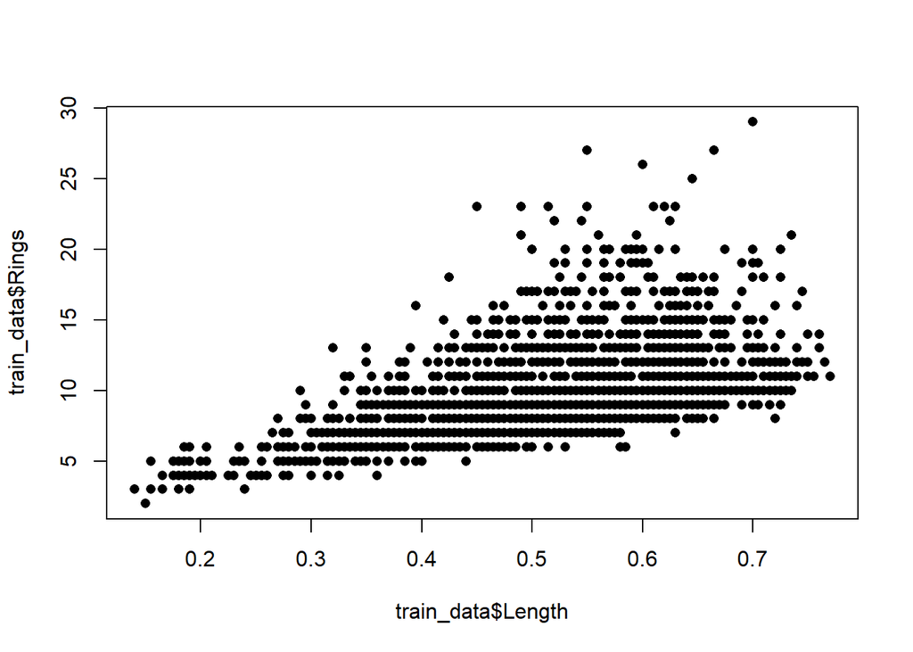

```r
#I will create plots of Rings vs every variable to try to visualize relationships
plot(train_data$Length, train_data$Rings,  #I will not formally name these plots, as these are exploratory, and not mandatory for the assignment
     pch = 16)
```

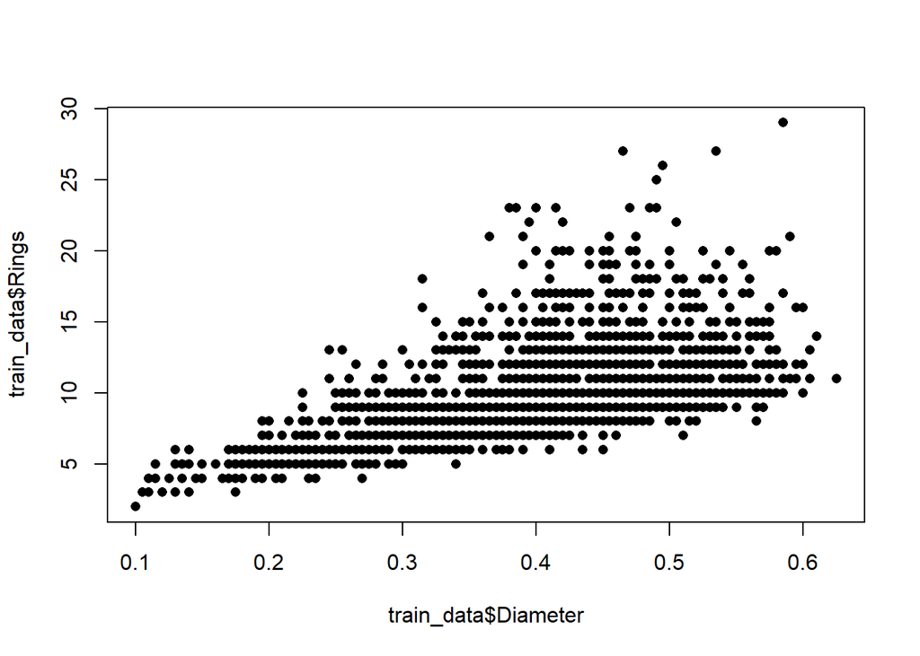

```r
plot(train_data$Diameter, train_data$Rings,  #I will not formally name these plots, as these are exploratory, and not mandatory for the assignment
     pch = 16)
```

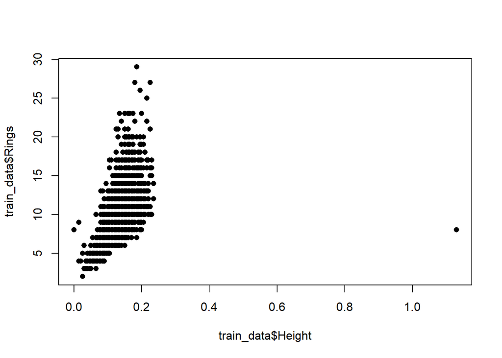

```r
plot(train_data$Height, train_data$Rings,  #I will not formally name these plots, as these are exploratory, and not mandatory for the assignment
     pch = 16)
```

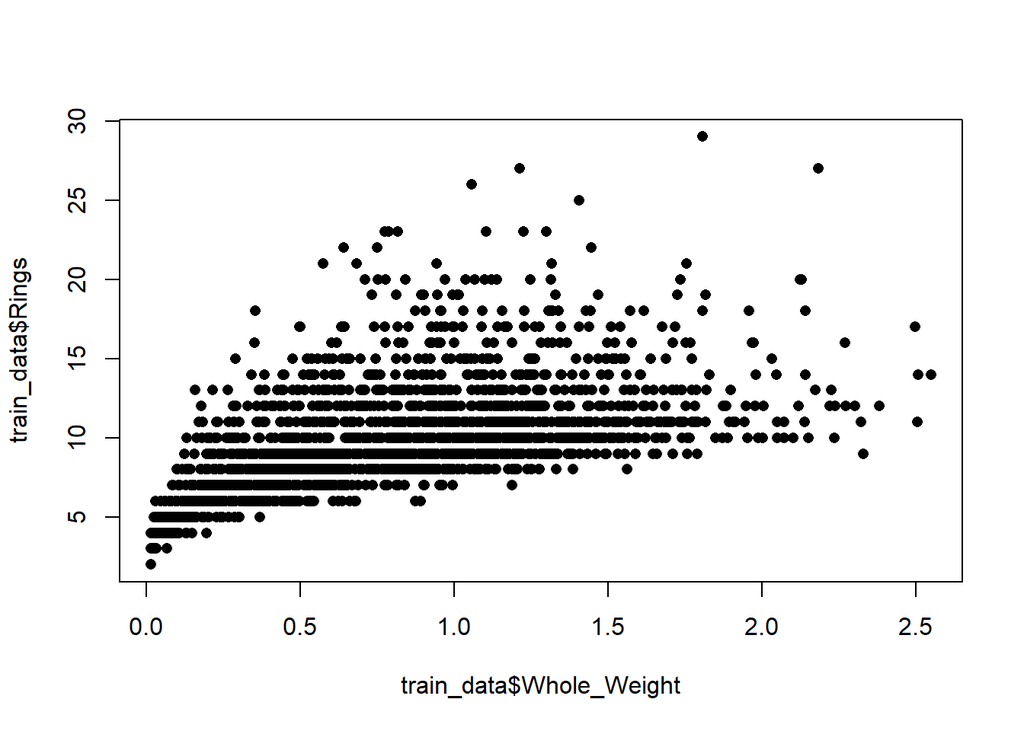

```r
plot(train_data$Whole_Weight, train_data$Rings,  #I will not formally name these plots, as these are exploratory, and not mandatory for the assignment
     pch = 16)
```

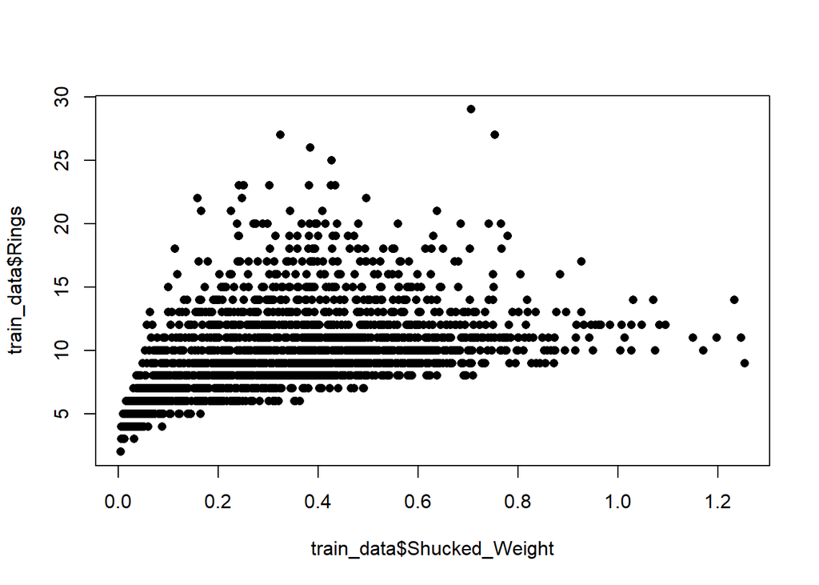

```r
plot(train_data$Shucked_Weight, train_data$Rings,  #I will not formally name these plots, as these are exploratory, and not mandatory for the assignment
     pch = 16)
```

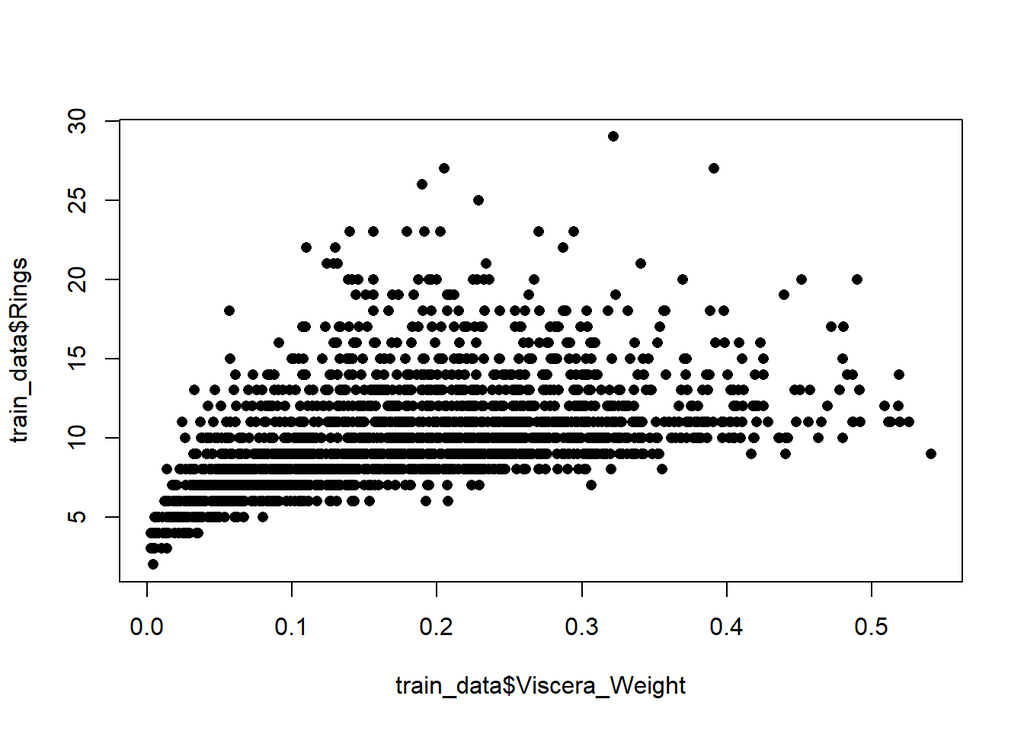

```r
plot(train_data$Viscera_Weight, train_data$Rings,  #I will not formally name these plots, as these are exploratory, and not mandatory for the assignment
     pch = 16)
```

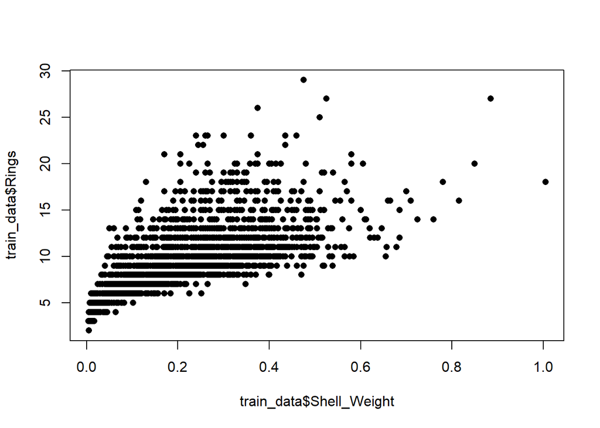

```r
plot(train_data$Shell_Weight, train_data$Rings,  #I will not formally name these plots, as these are exploratory, and not mandatory for the assignment
     pch = 16)
```

Observations:

- The length and diameter plots look identical. Both of them are heteroscedastic, so they are hard to work with.
- Height looks like it can be fit by an exponential model. There is also one severe outlier that looks to be a data-collection error, I will try to remove that.
- All the weight variables seem to have a logarithmic relation to rings

## Exercise 21c

```r
filtertrain_data <- filter(train_data, Height < 1, Rings < 21, Shell_Weight < 0.75)
myModellm <- lm(Rings~Height+factor(Sex)+I(log(Whole_Weight))*I(log(Shucked_Weight))*I(log(Viscera_Weight))*I(log(Shell_Weight)), data = filtertrain_data)
summary(myModellm)
```

```
Call:
lm(formula = Rings ~ Height + factor(Sex) + I(log(Whole_Weight)) *
    I(log(Shucked_Weight)) * I(log(Viscera_Weight)) * I(log(Shell_Weight)),
    data = filtertrain_data)

Residuals:
    Min      1Q  Median      3Q     Max
-6.6242 -1.2406 -0.2622  0.8782  9.1695

Coefficients:
                                                                                         Estimate
(Intercept)                                                                              -9.61443
Height                                                                                   12.25407
factor(Sex)I                                                                             -0.56337
factor(Sex)M                                                                              0.03131
I(log(Whole_Weight))                                                                     19.43998
I(log(Shucked_Weight))                                                                  -16.63185
I(log(Viscera_Weight))                                                                   -5.97608
I(log(Shell_Weight))                                                                     -4.81473
I(log(Whole_Weight)):I(log(Shucked_Weight))                                               1.68128
I(log(Whole_Weight)):I(log(Viscera_Weight))                                               0.95777
I(log(Shucked_Weight)):I(log(Viscera_Weight))                                            -1.67322
I(log(Whole_Weight)):I(log(Shell_Weight))                                                 4.32789
I(log(Shucked_Weight)):I(log(Shell_Weight))                                              -4.56075
I(log(Viscera_Weight)):I(log(Shell_Weight))                                              -2.39197
I(log(Whole_Weight)):I(log(Shucked_Weight)):I(log(Viscera_Weight))                        0.36129
I(log(Whole_Weight)):I(log(Shucked_Weight)):I(log(Shell_Weight))                          0.21770
I(log(Whole_Weight)):I(log(Viscera_Weight)):I(log(Shell_Weight))                         -0.16909
I(log(Shucked_Weight)):I(log(Viscera_Weight)):I(log(Shell_Weight))                       -0.61015
I(log(Whole_Weight)):I(log(Shucked_Weight)):I(log(Viscera_Weight)):I(log(Shell_Weight))  -0.01056
                                                                                        Std. Error
(Intercept)                                                                                4.29596
Height                                                                                     3.11645
factor(Sex)I                                                                               0.13573
factor(Sex)M                                                                               0.10768
I(log(Whole_Weight))                                                                       3.65848
I(log(Shucked_Weight))                                                                     3.41055
I(log(Viscera_Weight))                                                                     2.94323
I(log(Shell_Weight))                                                                       2.90110
I(log(Whole_Weight)):I(log(Shucked_Weight))                                                1.64107
```

[output cut: 61 more lines]

```
I(log(Shucked_Weight)):I(log(Viscera_Weight))
I(log(Whole_Weight)):I(log(Shell_Weight))                                               *
I(log(Shucked_Weight)):I(log(Shell_Weight))                                             .
I(log(Viscera_Weight)):I(log(Shell_Weight))
I(log(Whole_Weight)):I(log(Shucked_Weight)):I(log(Viscera_Weight))
I(log(Whole_Weight)):I(log(Shucked_Weight)):I(log(Shell_Weight))
I(log(Whole_Weight)):I(log(Viscera_Weight)):I(log(Shell_Weight))
I(log(Shucked_Weight)):I(log(Viscera_Weight)):I(log(Shell_Weight))
I(log(Whole_Weight)):I(log(Shucked_Weight)):I(log(Viscera_Weight)):I(log(Shell_Weight))
---
Signif. codes:  0 '***' 0.001 '**' 0.01 '*' 0.05 '.' 0.1 ' ' 1

Residual standard error: 1.981 on 2043 degrees of freedom
Multiple R-squared:  0.5801,    Adjusted R-squared:  0.5764
F-statistic: 156.8 on 18 and 2043 DF,  p-value: < 2.2e-16
```

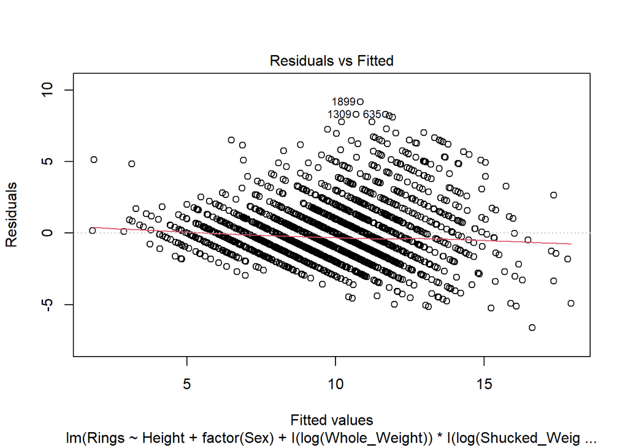

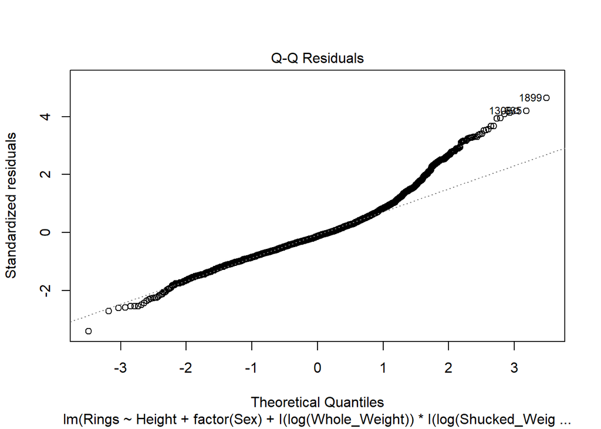

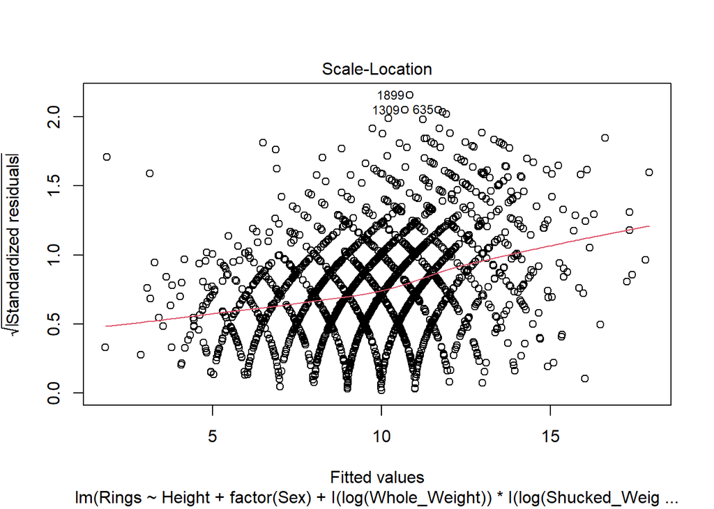

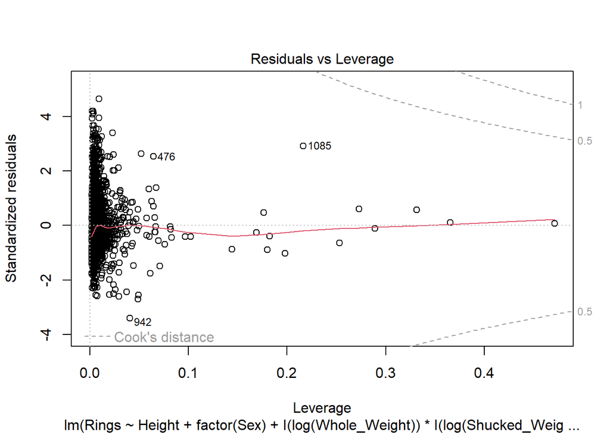

```r
e21R2 <- summary(myModellm)$adj.r.squared #for use in exercise 22
e21RSE <- summary(myModellm)$sigma #for use in exercise 22
testmyModellm <- predict(myModellm, test_data) #code taken from lab 2
e21MSE <- mean((test_data$Rings - testmyModellm)^2) #for use in exercise 22
plot(myModellm) #diagnostics
```

Unfortunately, the diagnostic plots show that this model still violates the assumptions of the linear model. I’m still not able to make the residuals normal, or the relationship homoscedastic. I’m not sure how to avoid this, I’d be happy to find out if there is a chance.

# Exercise 22

```r
table <- data.frame(
  Exercise = c("Exercise 5", "Exercise 10", "Exercise 11", "Exercise 15", "Exercise 17", "Exercise 18", "Exercise 19", "Exercise 21c"),
  AdjustedRSquared = c(e5R2, e10R2, e11R2, e15R2, e17R2, e18R2, e19R2, e21R2),
  RSETraining = c(e5RSE, e10RSE, e11RSE, e15RSE, e17RSE, e18RSE, e19RSE, e21RSE),
  MSETest = c(e5MSE, e10MSE, e11MSE, e15MSE, e17MSE, e18MSE, e19MSE, e21MSE)
)
kable(table)
```

| Exercise | AdjustedRSquared | RSETraining | MSETest |
| --- | --- | --- | --- |
| Exercise 5 | 0.3032374 | 2.777325 | 6.637220 |
| Exercise 10 | 0.3103183 | 2.763177 | 6.576065 |
| Exercise 11 | 0.3291185 | 2.725255 | 6.420192 |
| Exercise 15 | 0.3317552 | 2.719895 | 6.417419 |
| Exercise 17 | 0.3088525 | 2.766111 | 6.619032 |
| Exercise 18 | 0.3493521 | 2.683844 | 6.297586 |
| Exercise 19 | 0.5384046 | 2.260555 | 4.555382 |
| Exercise 21c | 0.5764350 | 1.981475 | 4.216368 |

# Exercise 23

The best choice would be the one made in Exercise 21, my personal model. It has the highest adjusted R-Squared, the lowest training RSE, and the lowest test MSE.

# Exercise 24

# Exercise 25

# Exercise 26